# Registered Report notebook: simulate

- Show All Code
- Hide All Code
- View Source

Author

Leonardo Capitani

Published

September 1, 2025

Modified

September 2, 2025

## Intro

I made this notebook to visualize how we are going to answer the research questions of the research project: Inferring and predicting plankton networks emergent properties in changing lakes.

**Note**

**Research questions:**

1. How do temperature, phosphorus and nitrogen levels have caused network emergent properties to vary?
2. How do invasive species presence/abundance have influenced network emergent properties?
3. How will plankton network emergent properties change in the near future (next 5-10 years)?

**Important**

**Plankton emergent properties**

## Load libraries

```r
library(here)
library(ggplot2)
library(dplyr)
library(tidyr)
library(purrr)
library(patchwork)
library(GPEDM)
set.seed(123)
```

GGplot theme

```r
newtheme <- theme_bw(base_size = 14)
theme_set(newtheme)
```

## Simulate abiotic drivers

```r
# ---- 1. Simulate drivers ----
n <- 200
Time <- 1:n
# we assume no causal link from Temp to Nutrients
temperature <- sin(2*pi*Time/50) + rnorm(n, 0, 0.3)   # seasonal + noise
phosphorus  <- sin(2*pi*Time/70 + 1) + rnorm(n, 0, 0.4)
nitrogen    <- sin(2*pi*Time/90 + 2) + rnorm(n, 0, 0.4)
```

```r
# ---- 2. Simulate emergent properties (hypotheses) ----
connectance <- 0.6*temperature + 0.3*nitrogen - 0.2*phosphorus +
               0.2*temperature*nitrogen + rnorm(n,0,0.2)

modularity  <- 0.5*phosphorus - 0.3*temperature +
               0.1*nitrogen*phosphorus + rnorm(n,0,0.2)

stability   <- -0.6*temperature - 0.5*phosphorus - 0.4*nitrogen +
               0.3*temperature*phosphorus + rnorm(n,0,0.2)

df <- data.frame(Time, temperature, phosphorus, nitrogen,
                 connectance, modularity, stability)
```

Add quagga mussel abundance

```r
# ---- Quagga mussel abundance ----
quagga <- rep(NA,n) # NA observation before time 100
quagga[Time > 100] <- runif(sum(Time > 100), 20, 200)  # random after 100

# Standardize (z-score)
quagga_std <- scale(quagga)

df <- df %>% mutate(quagga = as.numeric(quagga_std))
# ---- Reshape emergent properties for plotting ----
df_long <- df %>%
  pivot_longer(cols = c(connectance, modularity, stability),
               names_to = "property", values_to = "value")
```

### Visualize data

#### Time vs emergent properties

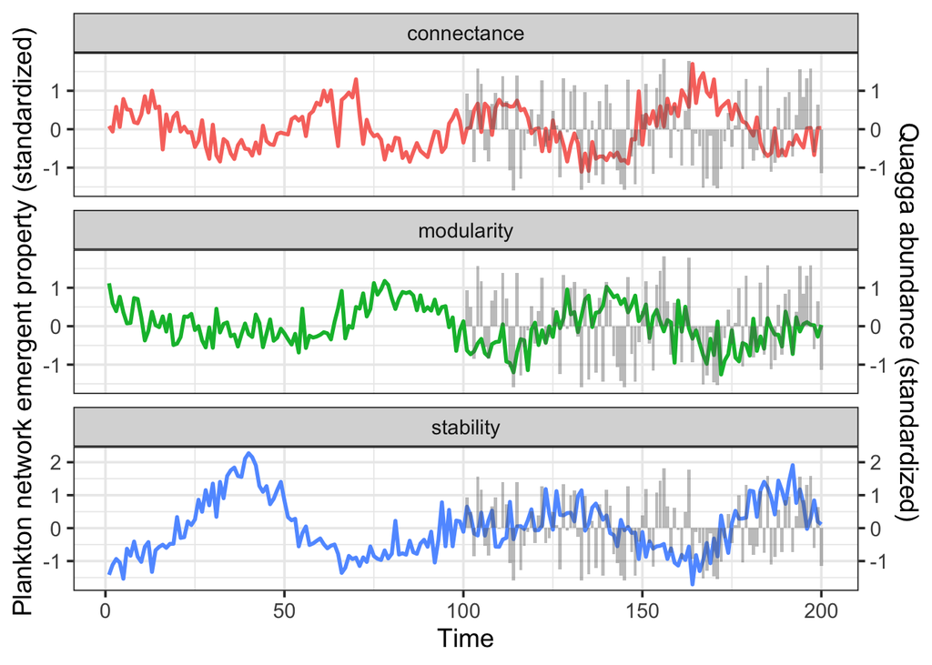

```r
# ---- Plot with facet wrap ----
p <- ggplot(df_long, aes(x = Time)) +
  geom_line(aes(y = value, color = property), size = 1) +
  geom_col(data = df, aes(y = quagga, x = Time),
           fill = "grey40", alpha = 0.4, inherit.aes = FALSE) +
  facet_wrap(~property, scales = "free_y", ncol = 1) +
  scale_y_continuous(
    name = "Plankton network emergent property (standardized)",
    sec.axis = sec_axis(~., name = "Quagga abundance (standardized)")
  ) +
  theme(legend.position = "none")

p
```

```r
# save as PNG
ggsave(here("outputs","figures","simulations","emergent_properties.png"), plot = p, width = 8, height = 6, dpi = 300)
```

## Load lake Zurich data

```r
p <- read.csv( here("data","data_raw","zurich","lake_zurich.csv")) |>   mutate(X = row_number())

# change species names
names(p)[names(p) == "Ci"] <- "Ciliates"
names(p)[names(p) == "Cr1"] <- "Cryptophytes (small)"
names(p)[names(p) == "Cr2"] <- "Cryptophytes (large)"
names(p)[names(p) == "Cy"] <- "Cyanobacteria"
names(p)[names(p) == "Di1"] <- "Diatoms (small)"
names(p)[names(p) == "Di2"] <- "Diatoms (large)"
names(p)[names(p) == "Go1"] <- "Gold algae (small)"
names(p)[names(p) == "Go2"] <- "Gold algae (large)"
names(p)[names(p) == "Gr1"] <- "Green algae (small)"
names(p)[names(p) == "Gr2"] <- "Green algae (large)"
names(p)[names(p) == "He"] <- "Large herbivores"
names(p)[names(p) == "Mi"] <- "Mixotrophic flagellates"
names(p)[names(p) == "Om"] <- "Omnivores"
names(p)[names(p) == "Pr"] <- "Invertebrate predators"
names(p)[names(p) == "Ro"] <- "Herbivore rotifers"
names(p)[names(p) == "temperature"] <- "Temperature"
names(p)[names(p) == "phosphorus"] <- "Phosphate"
```

### Visualize data

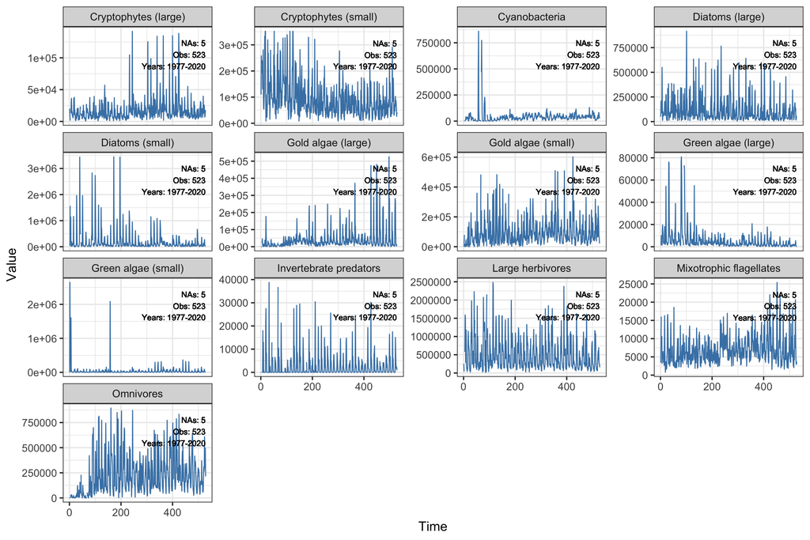

```r
# Separate abiotic and biotic variables
abiotic_vars <- c("Temperature", "Phosphate")

biotic_vars <- setdiff(names(p), c("X", "year", "month", "month_year", "quarter_year", abiotic_vars))

# Helper function to prepare p with stats
prepare_p <- function(df, vars) {
  df_long <- df %>%
    select(X, year, all_of(vars)) %>%
    pivot_longer(-c(X, year), names_to = "variable", values_to = "value")

  stats <- df_long %>%
    group_by(variable) %>%
    summarise(
      n_NA = sum(is.na(value)),
      n_obs = sum(!is.na(value)),
      start_year = min(year[!is.na(value)]),
      end_year = max(year[!is.na(value)]),
      .groups = "drop"
    )

  # Merge stats and calculate a fixed y-position (90% of max value)
  df_long <- df_long %>%
    left_join(stats, by = "variable") %>%
    group_by(variable) %>%
    mutate(y_pos = max(value, na.rm = TRUE) * 0.9) %>%
    ungroup()

  return(df_long)
}

# Prepare biotic and abiotic p
biotic_p <- prepare_p(p, biotic_vars)
abiotic_p <- prepare_p(p, abiotic_vars)

# Plot biotic variables
p_biotic <- ggplot(biotic_p, aes(x = X, y = value)) +
  geom_line(color = "steelblue") +
  facet_wrap(~variable, scales = "free_y") +
  geom_text(
    aes(
      x = max(X, na.rm = TRUE),
      y = y_pos,
      label = paste0("NAs: ", n_NA, "\nObs: ", n_obs, "\nYears: ", start_year, "-", end_year)
    ),
    hjust = 1, vjust = 1, size = 3, inherit.aes = FALSE
  ) +
  labs(x = "Time", y = "Value")

#
# Print plots
p_biotic
```

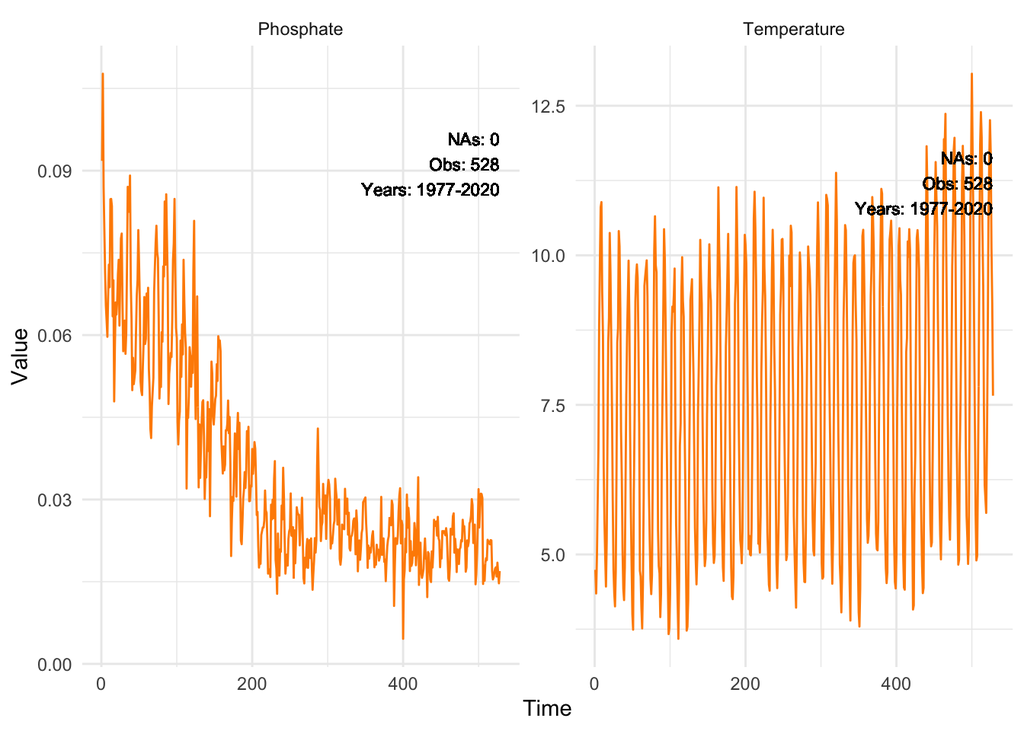

```r
p_abiotic <- ggplot(abiotic_p, aes(x = X, y = value)) +
  geom_line(color = "darkorange") +
  facet_wrap(~variable, scales = "free_y") +
  geom_text(
    aes(
      x = max(X, na.rm = TRUE),
      y = y_pos,
      label = paste0("NAs: ", n_NA, "\nObs: ", n_obs, "\nYears: ", start_year, "-", end_year)
    ),
    hjust = 1, vjust = 1, size = 3, inherit.aes = FALSE
  ) +
  theme_minimal() +
  labs(x = "Time", y = "Value")

p_abiotic
```

## Model emergent properties

If `E` and `tau` are supplied, the model uses the E/tau Method. If using the E/tau Method and multiple variables are listed under `x`, `fitGP` uses 𝐸 lags with spacing 𝜏 of *each* variable. If `E` and `tau` are omitted, the function will use the Custom Lags Method, using all the variables in `x` as predictors.

```r
m0 <- fitGP(data = df,


                  time = "Time",

                  y = "connectance", x = c("nitrogen", "phosphorus", "temperature"),

                   E = 1, tau = 1,

                  predictmethod = "loo", exclradius = 6)
```

## Conditional effects

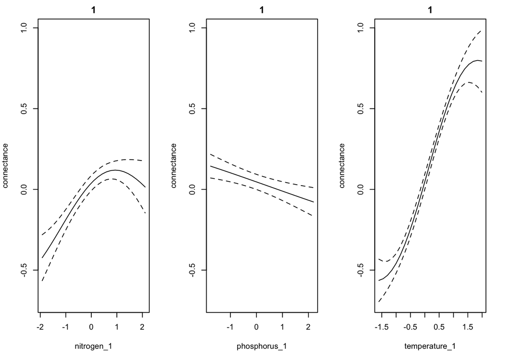

```r
con = getconditionals(m0)
```

Predictions:

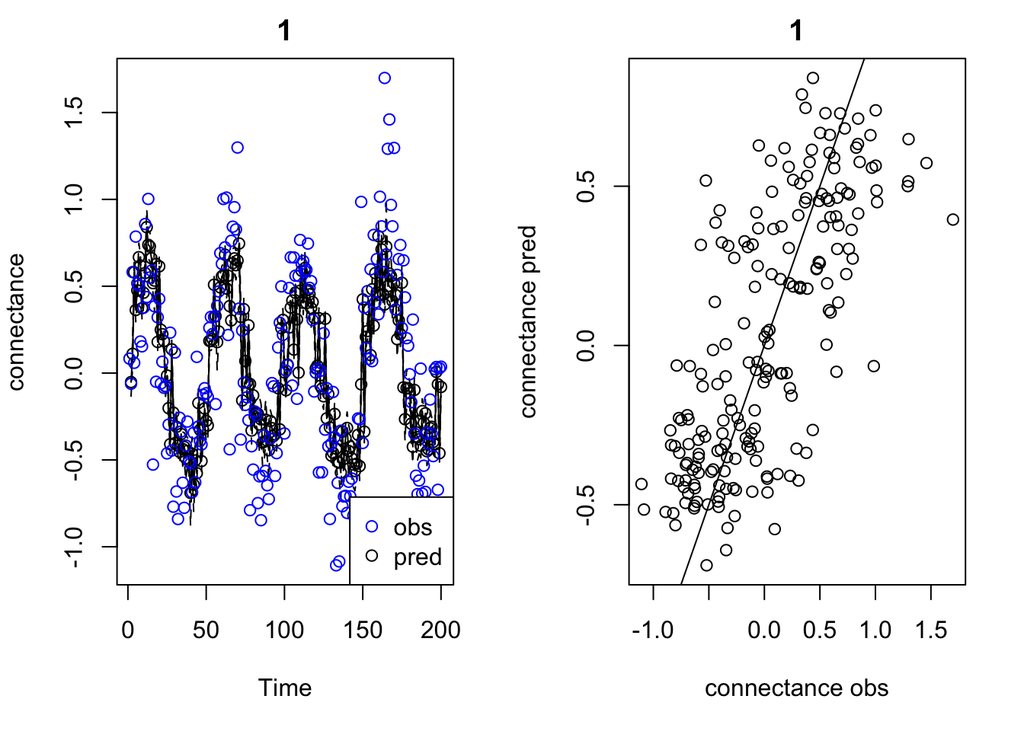

```r
plot(m0)
```

## References

Merz, E., Saberski, E., Gilarranz, L.J., Isles, P.D.F., Sugihara, G., Berger, C., *et al.* (2023). [Disruption of ecological networks in lakes by climate change and nutrient fluctuations](https://doi.org/10.1038/s41558-023-01615-6). *Nature Climate Change*, 13, 389–396.